# Course Project 1

Diego Costa

## Using RMarkdown to report an analysis

We will analize two months of data from an anonymous individual collected during the months of October and November, 2012 and include the number of steps taken in 5 minute intervals each day. The first step is to obtain the data, unzip it, and read it into R. Afterwards, the appropriate class will be asigned to dates.

```r
download.file("https://d396qusza40orc.cloudfront.net/repdata%2Fdata%2Factivity.zip", destfile = "data.zip")
unzip("data.zip")
data <- read.csv("activity.csv")
data$date <- as.Date(data$date)
```

Next, we’ll install some packages necessary for the analysis:

```r
library(ggplot2)
library(dplyr)
library(simputation)
library(lubridate)
```

Now, we’re ready to answer some questions:

### What is mean total number of steps taken per day?

First, a histogram with the total of steps per day:

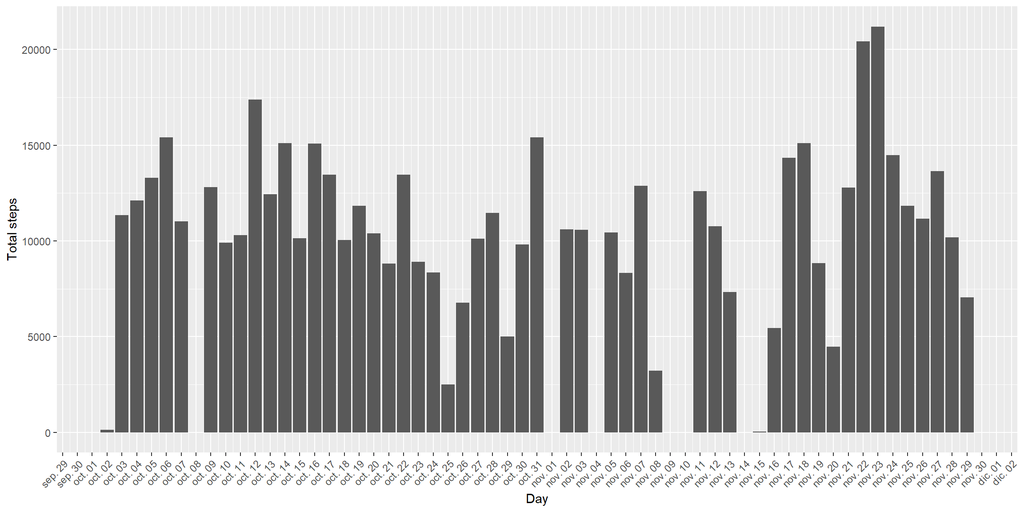

```r
ggplot(data, aes(data$date, data$steps)) + geom_histogram(stat = "identity")  + scale_x_date(date_breaks = "days", date_labels = "%b %d") + theme(axis.text.x = element_text(angle = 45, hjust = 1)) + labs(x = "Day", y = "Total steps")
```

Now, a table with the mean and median number of steps each day:

```r
Mean <- tapply(data$steps, data$date, mean, na.rm = TRUE)
Median <- tapply(data$steps, data$date, median, na.rm = TRUE)
table1 <- cbind(Mean, Median)
print(table1, type = "html")
```

```
##                  Mean Median
## 2012-10-01        NaN     NA
## 2012-10-02  0.4375000      0
## 2012-10-03 39.4166667      0
## 2012-10-04 42.0694444      0
## 2012-10-05 46.1597222      0
## 2012-10-06 53.5416667      0
## 2012-10-07 38.2465278      0
## 2012-10-08        NaN     NA
## 2012-10-09 44.4826389      0
## 2012-10-10 34.3750000      0
## 2012-10-11 35.7777778      0
## 2012-10-12 60.3541667      0
## 2012-10-13 43.1458333      0
## 2012-10-14 52.4236111      0
## 2012-10-15 35.2048611      0
## 2012-10-16 52.3750000      0
## 2012-10-17 46.7083333      0
## 2012-10-18 34.9166667      0
## 2012-10-19 41.0729167      0
## 2012-10-20 36.0937500      0
## 2012-10-21 30.6284722      0
## 2012-10-22 46.7361111      0
## 2012-10-23 30.9652778      0
## 2012-10-24 29.0104167      0
## 2012-10-25  8.6527778      0
## 2012-10-26 23.5347222      0
## 2012-10-27 35.1354167      0
## 2012-10-28 39.7847222      0
## 2012-10-29 17.4236111      0
## 2012-10-30 34.0937500      0
## 2012-10-31 53.5208333      0
## 2012-11-01        NaN     NA
## 2012-11-02 36.8055556      0
## 2012-11-03 36.7048611      0
## 2012-11-04        NaN     NA
## 2012-11-05 36.2465278      0
## 2012-11-06 28.9375000      0
## 2012-11-07 44.7326389      0
## 2012-11-08 11.1770833      0
## 2012-11-09        NaN     NA
## 2012-11-10        NaN     NA
## 2012-11-11 43.7777778      0
## 2012-11-12 37.3784722      0
## 2012-11-13 25.4722222      0
## 2012-11-14        NaN     NA
## 2012-11-15  0.1423611      0
## 2012-11-16 18.8923611      0
## 2012-11-17 49.7881944      0
## 2012-11-18 52.4652778      0
## 2012-11-19 30.6979167      0
## 2012-11-20 15.5277778      0
## 2012-11-21 44.3993056      0
## 2012-11-22 70.9270833      0
## 2012-11-23 73.5902778      0
## 2012-11-24 50.2708333      0
## 2012-11-25 41.0902778      0
## 2012-11-26 38.7569444      0
## 2012-11-27 47.3819444      0
## 2012-11-28 35.3576389      0
## 2012-11-29 24.4687500      0
## 2012-11-30        NaN     NA
```

### What is the average daily activity pattern?

We’ll make a time-series plot with the average number of steps taken per 5-minute interval across all days:

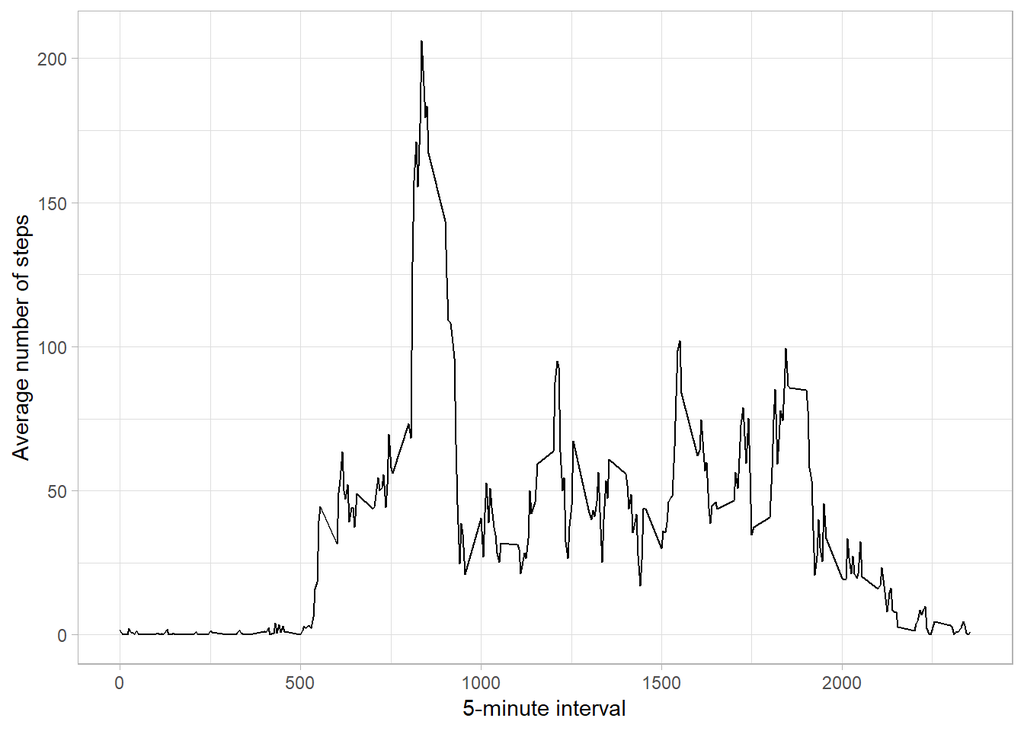

```r
ggplot(data, aes(data$interval, data$steps)) + geom_line(stat= "summary", fun.y = "mean") + labs(x = "5-minute interval", y = "Average number of steps") + theme_light()
```

Now, lets find the interval with the highest average steps.

```r
averages <- aggregate(data$steps, list(data$interval), mean, na.rm = TRUE)
max_average <- round(max(averages$x))
max_interval <- averages$Group.1[averages$x == max(averages$x)]
```

The maximum average of steps per interval is **206**. The corresponding 5-minute interval is **835**.

### Imputing missing values

```r
missing <- is.na(data$steps)
missing_sum <- sum(missing)
```

The amount of missing values is **2304**.

Using the package *simputation*, we’ll impute the mean value of the corresponding interval for each NA in steps, and create a dataset with the imputed values.

```r
m_data <- data
m_data <- impute_proxy(m_data, steps ~ mean(steps,na.rm=TRUE) | interval)
```

The histogram for the data with imputed missing values is:

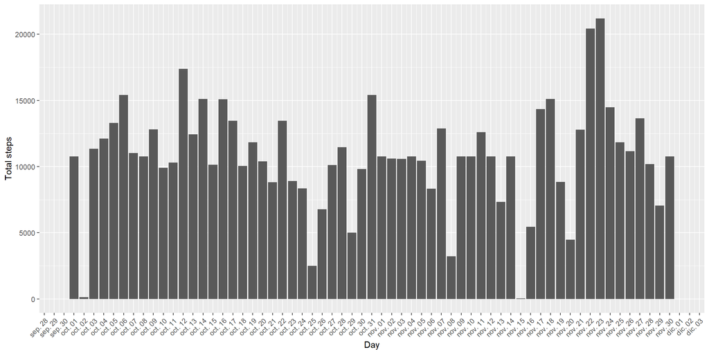

```r
ggplot(m_data, aes(m_data$date, m_data$steps)) + geom_histogram(stat = "identity")  + scale_x_date(date_breaks = "days", date_labels = "%b %d") + theme(axis.text.x = element_text(angle = 45, hjust = 1)) + labs(x = "Day", y = "Total steps")
```

Next, a table of the mean and median step per day accounting for the imputed missing values:

```r
m_Mean <- tapply(m_data$steps, m_data$date, mean, na.rm = T)
m_Median <- tapply(m_data$steps, m_data$date, median, na.rm = T)
table2 <- cbind(m_Mean, m_Median)
print(table2, type = "html")
```

```
##                m_Mean m_Median
## 2012-10-01 37.3825996 34.11321
## 2012-10-02  0.4375000  0.00000
## 2012-10-03 39.4166667  0.00000
## 2012-10-04 42.0694444  0.00000
## 2012-10-05 46.1597222  0.00000
## 2012-10-06 53.5416667  0.00000
## 2012-10-07 38.2465278  0.00000
## 2012-10-08 37.3825996 34.11321
## 2012-10-09 44.4826389  0.00000
## 2012-10-10 34.3750000  0.00000
## 2012-10-11 35.7777778  0.00000
## 2012-10-12 60.3541667  0.00000
## 2012-10-13 43.1458333  0.00000
## 2012-10-14 52.4236111  0.00000
## 2012-10-15 35.2048611  0.00000
## 2012-10-16 52.3750000  0.00000
## 2012-10-17 46.7083333  0.00000
## 2012-10-18 34.9166667  0.00000
## 2012-10-19 41.0729167  0.00000
## 2012-10-20 36.0937500  0.00000
## 2012-10-21 30.6284722  0.00000
## 2012-10-22 46.7361111  0.00000
## 2012-10-23 30.9652778  0.00000
## 2012-10-24 29.0104167  0.00000
## 2012-10-25  8.6527778  0.00000
## 2012-10-26 23.5347222  0.00000
## 2012-10-27 35.1354167  0.00000
## 2012-10-28 39.7847222  0.00000
## 2012-10-29 17.4236111  0.00000
## 2012-10-30 34.0937500  0.00000
## 2012-10-31 53.5208333  0.00000
## 2012-11-01 37.3825996 34.11321
## 2012-11-02 36.8055556  0.00000
## 2012-11-03 36.7048611  0.00000
## 2012-11-04 37.3825996 34.11321
## 2012-11-05 36.2465278  0.00000
## 2012-11-06 28.9375000  0.00000
## 2012-11-07 44.7326389  0.00000
## 2012-11-08 11.1770833  0.00000
## 2012-11-09 37.3825996 34.11321
## 2012-11-10 37.3825996 34.11321
## 2012-11-11 43.7777778  0.00000
## 2012-11-12 37.3784722  0.00000
## 2012-11-13 25.4722222  0.00000
## 2012-11-14 37.3825996 34.11321
## 2012-11-15  0.1423611  0.00000
## 2012-11-16 18.8923611  0.00000
## 2012-11-17 49.7881944  0.00000
## 2012-11-18 52.4652778  0.00000
## 2012-11-19 30.6979167  0.00000
## 2012-11-20 15.5277778  0.00000
## 2012-11-21 44.3993056  0.00000
## 2012-11-22 70.9270833  0.00000
## 2012-11-23 73.5902778  0.00000
## 2012-11-24 50.2708333  0.00000
## 2012-11-25 41.0902778  0.00000
## 2012-11-26 38.7569444  0.00000
## 2012-11-27 47.3819444  0.00000
## 2012-11-28 35.3576389  0.00000
## 2012-11-29 24.4687500  0.00000
## 2012-11-30 37.3825996 34.11321
```

### Are there differences in activity patterns between weekdays and weekends?

First. we’ll creat a variable that tell’s us the weekday, and then divide it in “Weekdays” and “Weekend”.

```r
m_data$wd <- wday(m_data$date)
m_data$wd <- ifelse(m_data$wd == 2 | m_data$wd == 3 | m_data$wd == 4 | m_data$wd == 5 | m_data$wd == 6, "1", "0")
m_data$wd <- factor(m_data$wd, levels = c(0, 1), labels = c("Weekends", "Weekdays"))
```

Now, a time-series plot with the average number of steps taken per 5-minute interval comparing weekdays and weekends.

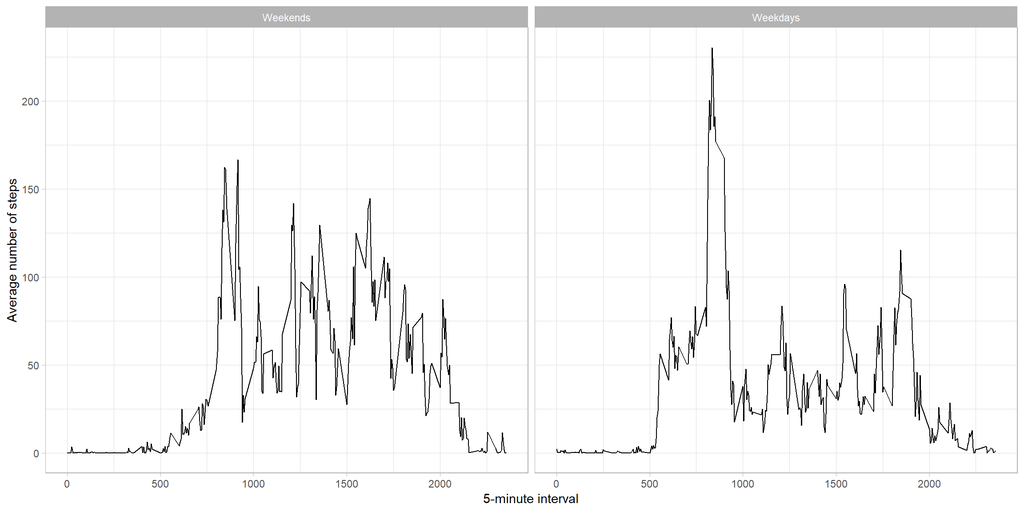

```r
ggplot(m_data, aes(m_data$interval, m_data$steps)) + geom_line(stat= "summary", fun.y = "mean") + labs(x = "5-minute interval", y = "Average number of steps") + theme_light() + facet_grid(m_data$wd)
```